# Red Wine Quality Analysis

by Gerrit Tombrink

# Introduction

This dataset was used for a Udacity project and the dataset is publicly available for research. All details are described in (Cortez et al., 2009), see:

(P. Cortez, A. Cerdeira, F. Almeida, T. Matos and J. Reis. Modeling wine preferences by data mining from physicochemical properties. In Decision Support Systems, Elsevier, 47(4):547-553. ISSN: 0167-9236.)

The dataset consists of the following variables and data formats:

```
## 'data.frame':    1599 obs. of  13 variables:
##  $ X                   : int  1 2 3 4 5 6 7 8 9 10 ...
##  $ fixed.acidity       : num  7.4 7.8 7.8 11.2 7.4 7.4 7.9 7.3 7.8 7.5 ...
##  $ volatile.acidity    : num  0.7 0.88 0.76 0.28 0.7 0.66 0.6 0.65 0.58 0.5 ...
##  $ citric.acid         : num  0 0 0.04 0.56 0 0 0.06 0 0.02 0.36 ...
##  $ residual.sugar      : num  1.9 2.6 2.3 1.9 1.9 1.8 1.6 1.2 2 6.1 ...
##  $ chlorides           : num  0.076 0.098 0.092 0.075 0.076 0.075 0.069 0.065 0.073 0.071 ...
##  $ free.sulfur.dioxide : num  11 25 15 17 11 13 15 15 9 17 ...
##  $ total.sulfur.dioxide: num  34 67 54 60 34 40 59 21 18 102 ...
##  $ density             : num  0.998 0.997 0.997 0.998 0.998 ...
##  $ pH                  : num  3.51 3.2 3.26 3.16 3.51 3.51 3.3 3.39 3.36 3.35 ...
##  $ sulphates           : num  0.56 0.68 0.65 0.58 0.56 0.56 0.46 0.47 0.57 0.8 ...
##  $ alcohol             : num  9.4 9.8 9.8 9.8 9.4 9.4 9.4 10 9.5 10.5 ...
##  $ quality             : int  5 5 5 6 5 5 5 7 7 5 ...
```

The statistics for each variable are as follows:

```
##        X          fixed.acidity   volatile.acidity  citric.acid
##  Min.   :   1.0   Min.   : 4.60   Min.   :0.1200   Min.   :0.000
##  1st Qu.: 400.5   1st Qu.: 7.10   1st Qu.:0.3900   1st Qu.:0.090
##  Median : 800.0   Median : 7.90   Median :0.5200   Median :0.260
##  Mean   : 800.0   Mean   : 8.32   Mean   :0.5278   Mean   :0.271
##  3rd Qu.:1199.5   3rd Qu.: 9.20   3rd Qu.:0.6400   3rd Qu.:0.420
##  Max.   :1599.0   Max.   :15.90   Max.   :1.5800   Max.   :1.000
##  residual.sugar     chlorides       free.sulfur.dioxide
##  Min.   : 0.900   Min.   :0.01200   Min.   : 1.00
##  1st Qu.: 1.900   1st Qu.:0.07000   1st Qu.: 7.00
##  Median : 2.200   Median :0.07900   Median :14.00
##  Mean   : 2.539   Mean   :0.08747   Mean   :15.87
##  3rd Qu.: 2.600   3rd Qu.:0.09000   3rd Qu.:21.00
##  Max.   :15.500   Max.   :0.61100   Max.   :72.00
##  total.sulfur.dioxide    density             pH          sulphates
##  Min.   :  6.00       Min.   :0.9901   Min.   :2.740   Min.   :0.3300
##  1st Qu.: 22.00       1st Qu.:0.9956   1st Qu.:3.210   1st Qu.:0.5500
##  Median : 38.00       Median :0.9968   Median :3.310   Median :0.6200
##  Mean   : 46.47       Mean   :0.9967   Mean   :3.311   Mean   :0.6581
##  3rd Qu.: 62.00       3rd Qu.:0.9978   3rd Qu.:3.400   3rd Qu.:0.7300
##  Max.   :289.00       Max.   :1.0037   Max.   :4.010   Max.   :2.0000
##     alcohol         quality
##  Min.   : 8.40   Min.   :3.000
##  1st Qu.: 9.50   1st Qu.:5.000
##  Median :10.20   Median :6.000
##  Mean   :10.42   Mean   :5.636
##  3rd Qu.:11.10   3rd Qu.:6.000
##  Max.   :14.90   Max.   :8.000
```

Overall, this red wine dataset contains 1599 red wines including 11 chemical variables with the following units:

- fixed acidity (tartaric acid - g / dm^3)
- volatile acidity (acetic acid - g / dm^3)
- citric acid (g / dm^3)
- residual sugar (g / dm^3)
- chlorides (sodium chloride - g / dm^3
- free sulfur dioxide (mg / dm^3)
- total sulfur dioxide (mg / dm^3)
- density (g / cm^3)
- pH
- sulphates (potassium sulphate - g / dm3)
- alcohol (% by volume)

In addition, the quality of the wine was recorded by a score between 1 and 12 (see quality column). Based on these variables, the aim of this report is to analyze the correlation between the chemical properties and the quality of the red wines.

# Univariate Plots Section

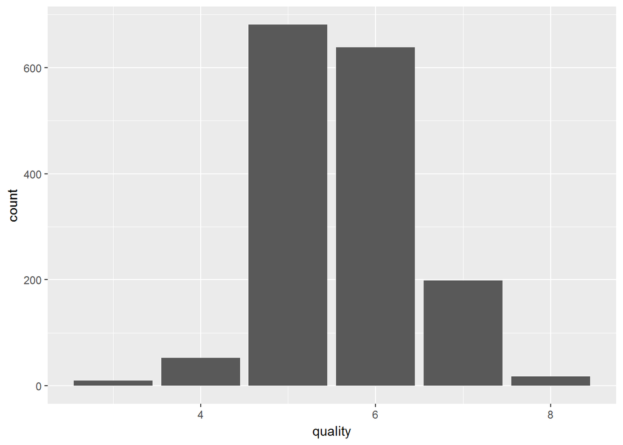

```
##    Min. 1st Qu.  Median    Mean 3rd Qu.    Max.
##   3.000   5.000   6.000   5.636   6.000   8.000
```

According to the dataset description, the wine quality scale is usually between 0 and 12. This red wine dataset does not use the total wine quality scale: With the help of this red wine quality plot, it can be shown that the lowest quality value is 3 and the maximum quality value is 8. The median of this variable is 6.

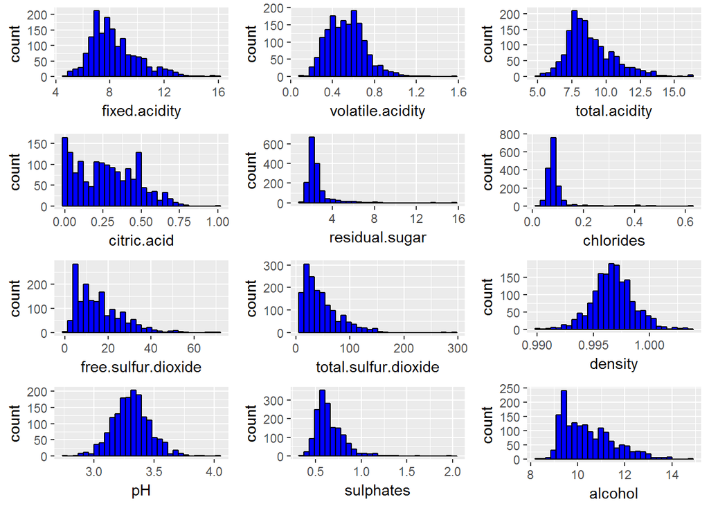

Each of the histograms shown here can be summarized as follows:

- Fixed acidity: it is a low right skewed histogram
- Volatile acidity: it is a low right skewed histogram
- Total acidity: it is a low right skewed histogram
- Citric acid: it is a strong right skewed histogram with the highest peak at 0.0
- Residual sugar: it is a strong right skewed histogram with the highest peaks between 0 and 4
- Chlorides: it is a strong right skewed histogram with the highest peaks between 0 and 0.1
- Free sulfur dioxide: it is a strong right skewed histogram
- Total sulfur dioxide: it is a strong right skewed histogram
- Density: the values are almost normal distributed
- pH: the values are almost normal distributed
- Sulphates: it is a right-skewed histogram
- Alcohol: it is a right-skewed histogram

The distributions of values within the histograms show that only the values of “density” and “pH” are almost normally distributed.

### Rescaling variables

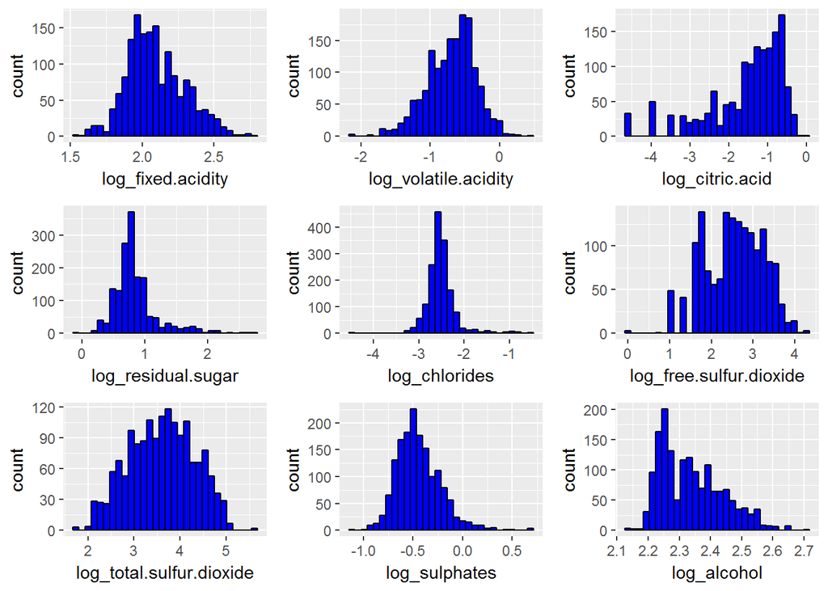

The log function helps to plot more normal distributed histograms.

# Univariate Analysis

Overall, the dataset contains 1599 red wines including 11 chemical variables and one variable about the wine quality. The wine quality variable based on ratings by experts. However, this quality classification is not based on a measurement but on a subjective perception of the expert. Therefore, it makes sense to correlate this subjective variable with the measured chemical variables.

Two (density and pH) of the eleven chemical variables are almost normally distributed. Within all histograms, there are no bimodal or multimodal distributions. Therefore, a reclassification should not be preferred. Because the dataset separate fixed and volatile acidity, a combination of both into a total amount variable could help to understand the distribution of this variable. Therefore, both variables were summed and implemented as a variable “total.acidity” in the dataset. Additionally, with the help of log functions skewed histograms could be transformed into an almost normal distribution.

# Bivariate Plots Section

To plot and correlate each variables’ impact on quality, the following Figures were created:

### Variable: Fixed acidity

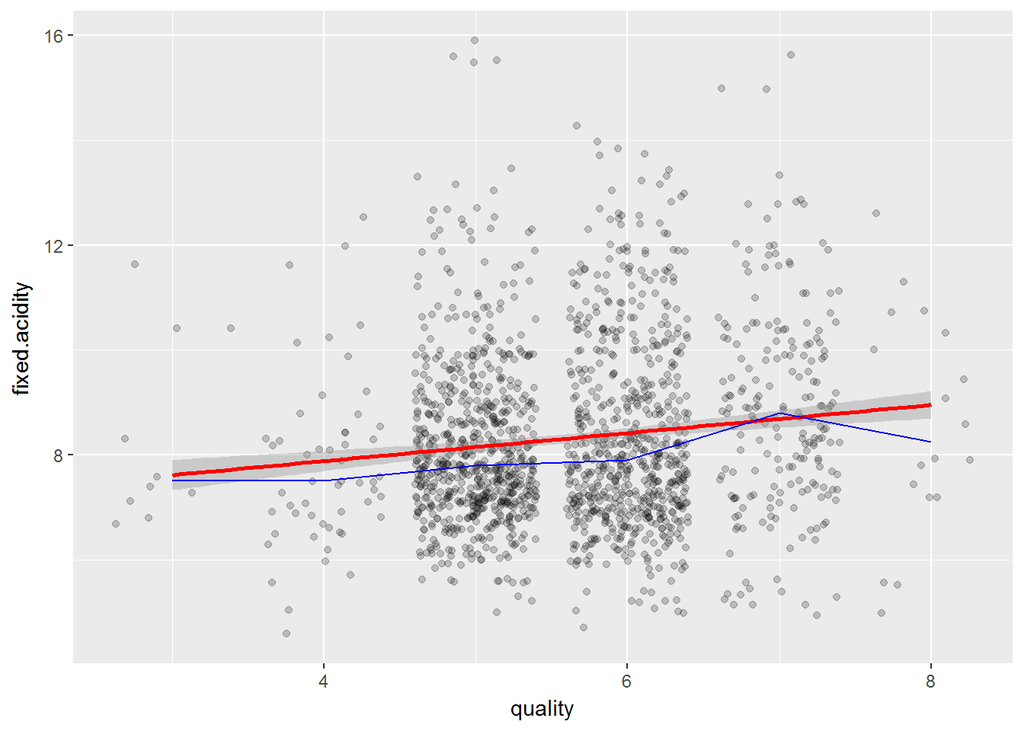

```
##
##  Pearson's product-moment correlation
##
## data:  rw_data$quality and rw_data$fixed.acidity
## t = 4.996, df = 1597, p-value = 6.496e-07
## alternative hypothesis: true correlation is not equal to 0
## 95 percent confidence interval:
##  0.07548957 0.17202667
## sample estimates:
##       cor
## 0.1240516
```

The correlation coefficient of the variable fixed acidity is 0.1240516. This variable has no meaningful impact.

### Variable: Volatile acidity

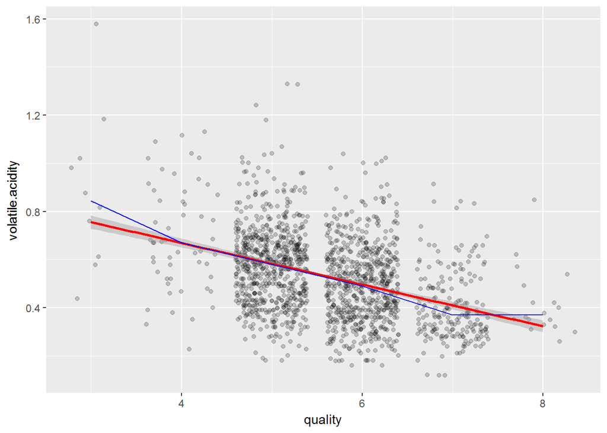

```
##
##  Pearson's product-moment correlation
##
## data:  rw_data$quality and rw_data$volatile.acidity
## t = -16.954, df = 1597, p-value < 2.2e-16
## alternative hypothesis: true correlation is not equal to 0
## 95 percent confidence interval:
##  -0.4313210 -0.3482032
## sample estimates:
##        cor
## -0.3905578
```

The correlation coefficient of the variable volatile acidity is -0.3905578. This variable has a small impact.

### Variable: Total acidity

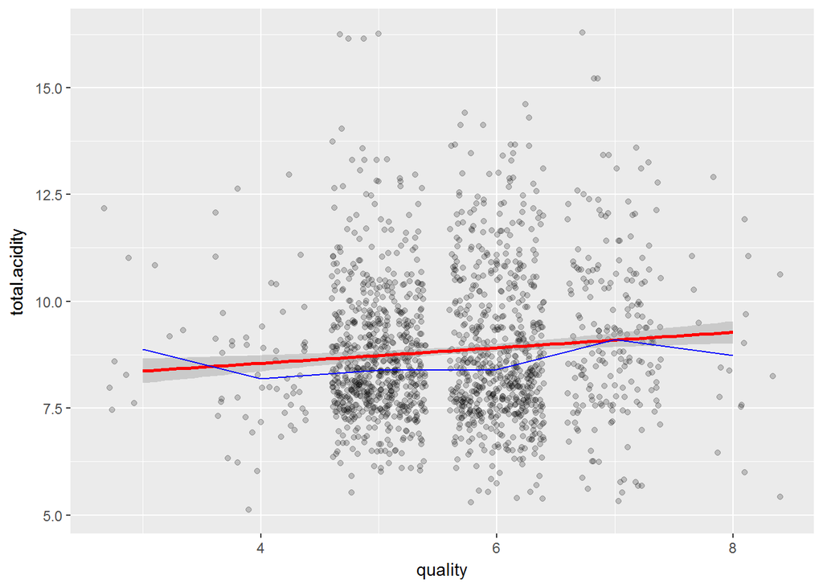

```
##
##  Pearson's product-moment correlation
##
## data:  rw_data$quality and rw_data$total.acidity
## t = 3.4378, df = 1597, p-value = 0.0006015
## alternative hypothesis: true correlation is not equal to 0
## 95 percent confidence interval:
##  0.03684298 0.13416675
## sample estimates:
##        cor
## 0.08570932
```

The correlation coefficient of the variable total acidity is 0.08570932. This variable has no meaningful impact.

### Variable: Citric acid

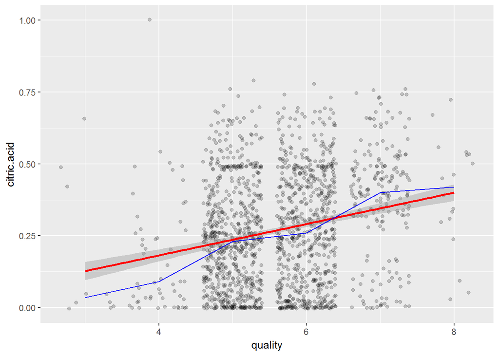

```
##
##  Pearson's product-moment correlation
##
## data:  rw_data$quality and rw_data$citric.acid
## t = 9.2875, df = 1597, p-value < 2.2e-16
## alternative hypothesis: true correlation is not equal to 0
## 95 percent confidence interval:
##  0.1793415 0.2723711
## sample estimates:
##       cor
## 0.2263725
```

The correlation coefficient of the variable citric acid is 0.2263725. This variable has a very small impact.

### Variable: Residual sugar

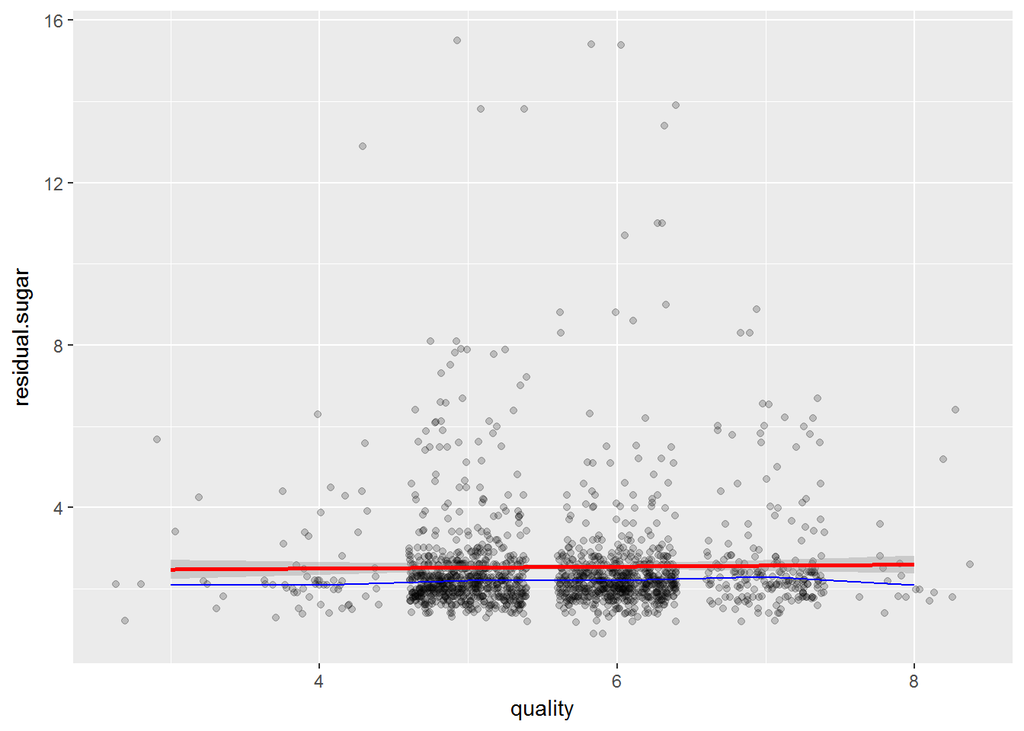

```
##
##  Pearson's product-moment correlation
##
## data:  rw_data$quality and rw_data$residual.sugar
## t = 0.5488, df = 1597, p-value = 0.5832
## alternative hypothesis: true correlation is not equal to 0
## 95 percent confidence interval:
##  -0.03531327  0.06271056
## sample estimates:
##        cor
## 0.01373164
```

The correlation coefficient of the variable residual sugar is 0.01373164. This variable has no meaningful impact.

### Variable: Chlorides

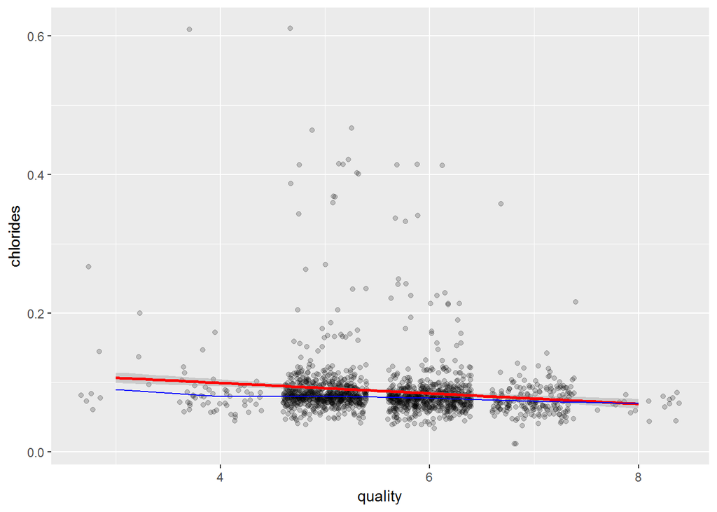

```
##
##  Pearson's product-moment correlation
##
## data:  rw_data$quality and rw_data$chlorides
## t = -5.1948, df = 1597, p-value = 2.313e-07
## alternative hypothesis: true correlation is not equal to 0
## 95 percent confidence interval:
##  -0.17681041 -0.08039344
## sample estimates:
##        cor
## -0.1289066
```

The correlation coefficient of the variable chlorides is -0.1289066. This variable has no meaningful impact.

### Variable: Free sulfur dioxide

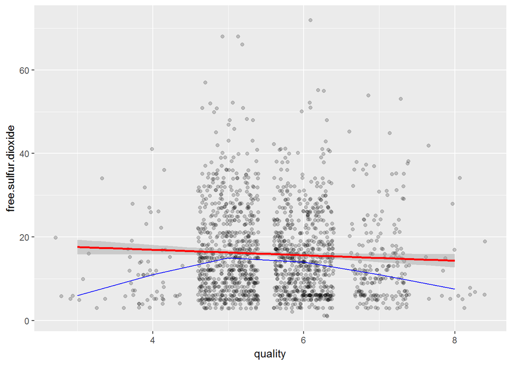

```
##
##  Pearson's product-moment correlation
##
## data:  rw_data$quality and rw_data$free.sulfur.dioxide
## t = -2.0269, df = 1597, p-value = 0.04283
## alternative hypothesis: true correlation is not equal to 0
## 95 percent confidence interval:
##  -0.099430290 -0.001638987
## sample estimates:
##         cor
## -0.05065606
```

The correlation coefficient of the variable free sulfur dioxide is -0.05065606. This variable has no meaningful impact.

### Variable: Total sulfur dioxide

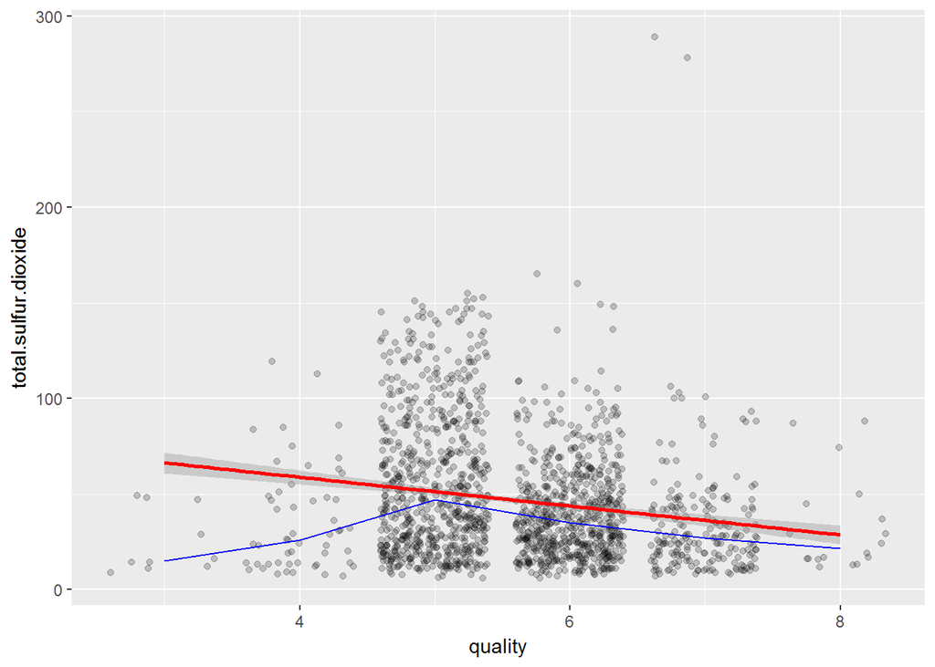

```
##
##  Pearson's product-moment correlation
##
## data:  rw_data$quality and rw_data$total.sulfur.dioxide
## t = -7.5271, df = 1597, p-value = 8.622e-14
## alternative hypothesis: true correlation is not equal to 0
## 95 percent confidence interval:
##  -0.2320162 -0.1373252
## sample estimates:
##        cor
## -0.1851003
```

The correlation coefficient of the variable total sulfur dioxide is -0.1851003. This variable has no meaningful impact.

### Variable: Density

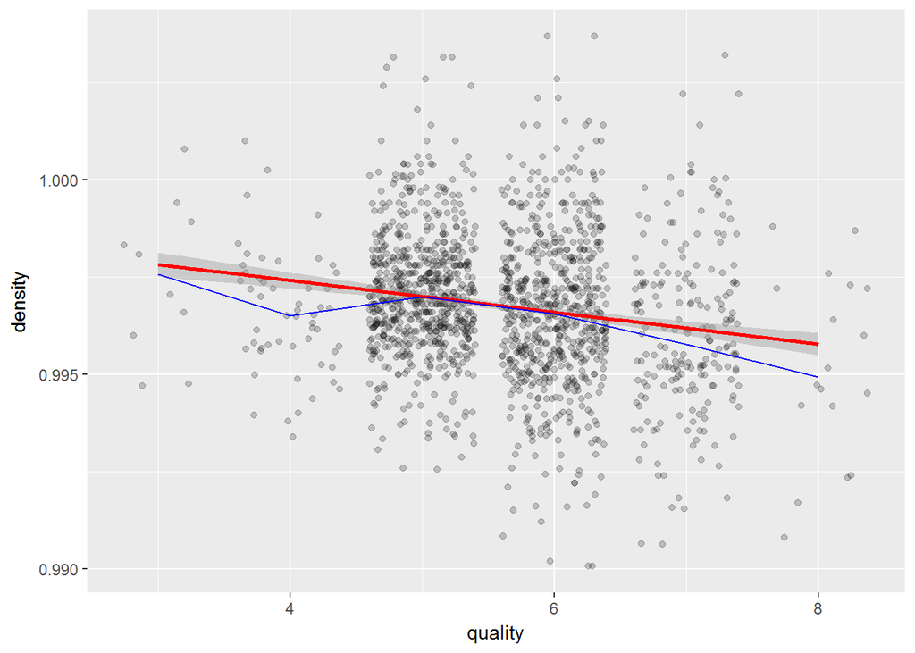

```
##
##  Pearson's product-moment correlation
##
## data:  rw_data$quality and rw_data$density
## t = -7.0997, df = 1597, p-value = 1.875e-12
## alternative hypothesis: true correlation is not equal to 0
## 95 percent confidence interval:
##  -0.2220365 -0.1269870
## sample estimates:
##        cor
## -0.1749192
```

The correlation coefficient of the variable density is -0.1749192. This variable has no meaningful impact.

### Variable: pH

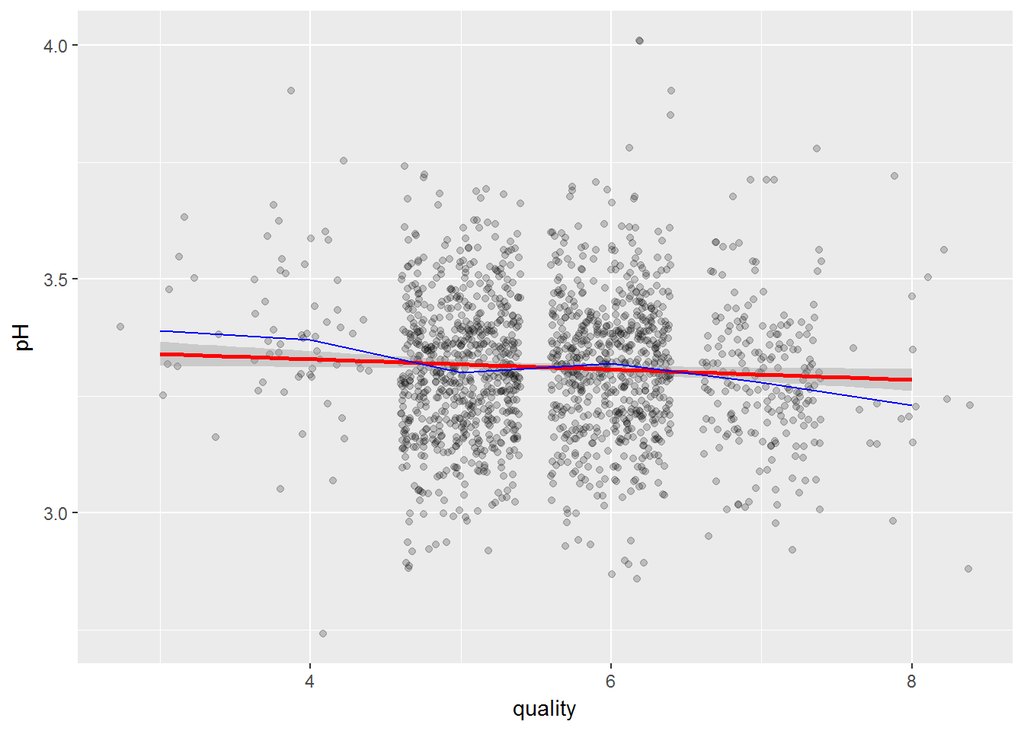

```
##
##  Pearson's product-moment correlation
##
## data:  rw_data$quality and rw_data$pH
## t = -2.3109, df = 1597, p-value = 0.02096
## alternative hypothesis: true correlation is not equal to 0
## 95 percent confidence interval:
##  -0.106451268 -0.008734972
## sample estimates:
##         cor
## -0.05773139
```

The correlation coefficient of the variable pH is -0.05773139. This variable has no meaningful impact.

### Variable: Sulphates

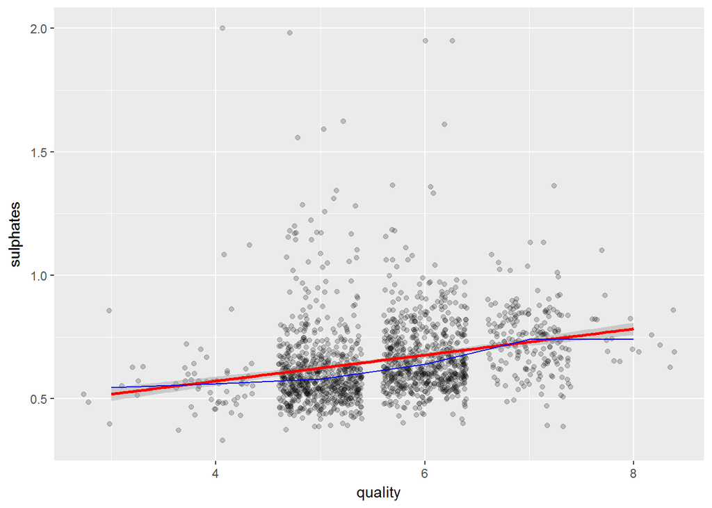

```
##
##  Pearson's product-moment correlation
##
## data:  rw_data$quality and rw_data$sulphates
## t = 10.38, df = 1597, p-value < 2.2e-16
## alternative hypothesis: true correlation is not equal to 0
## 95 percent confidence interval:
##  0.2049011 0.2967610
## sample estimates:
##       cor
## 0.2513971
```

The correlation coefficient of the variable sulphates is 0.2513971. This variable has a very small impact.

### Variable: Alcohol

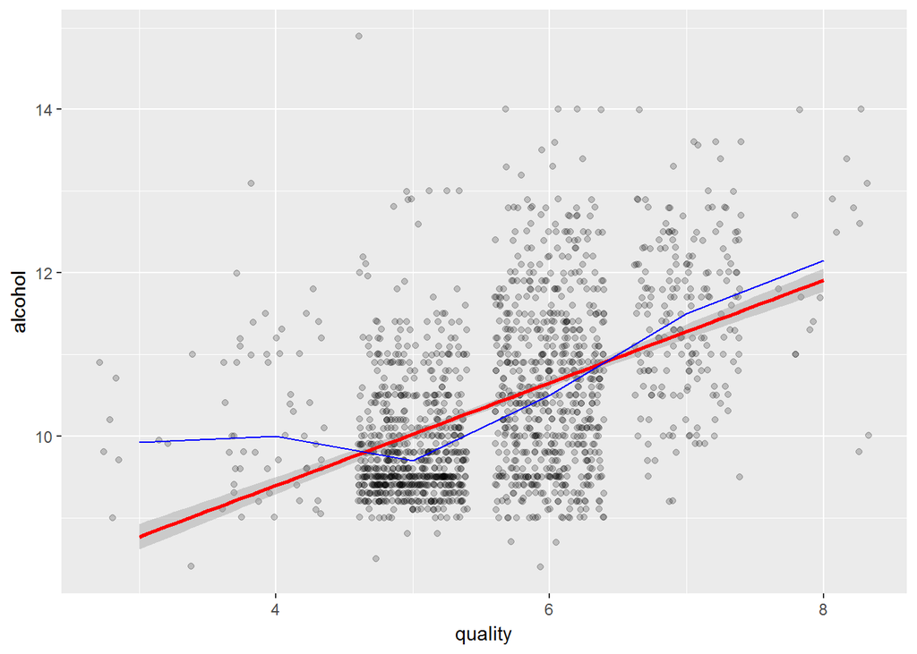

```
##
##  Pearson's product-moment correlation
##
## data:  rw_data$quality and rw_data$alcohol
## t = 21.639, df = 1597, p-value < 2.2e-16
## alternative hypothesis: true correlation is not equal to 0
## 95 percent confidence interval:
##  0.4373540 0.5132081
## sample estimates:
##       cor
## 0.4761663
```

The correlation coefficient of the variable alcohol is 0.4761663. This variable has a small to moderate impact.

# Bivariate Analysis

As a result of these analyses it could be clarified that the following variables have higher correlations to the variable “quality”:

- 1. Alcohol has a correlation of 0.4761663 to “quality” (small to moderate impact).
- 2. Volatile acidity has a correlation of -0.3905578 to “quality” (small impact).
- 3. Sulphates have a correlation of 0.2513971 to “quality” (very small impact).
- 4. Citric acid has a correlation of 0.2263725 to “quality” (very small impact).

The variable alcohol has the biggest impact on the quality of the red wine. This can be clarified with the median distribution:

```
## # A tibble: 6 x 4
##   quality alcohol_mean alcohol_median     n
##     <int>        <dbl>          <dbl> <int>
## 1       3         9.96           9.93    10
## 2       4        10.3           10       53
## 3       5         9.90           9.7    681
## 4       6        10.6           10.5    638
## 5       7        11.5           11.5    199
## 6       8        12.1           12.2     18
```

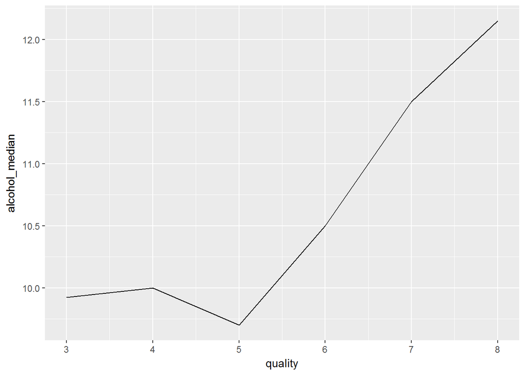

This plot shows that an increasing alcohol content is associated with a higher quality of the red wine.

Additional evidence about dependencies between different variables provides a correlation matrix:

```
##                                 X fixed.acidity volatile.acidity
## X                     1.000000000   -0.26848392     -0.008815099
## fixed.acidity        -0.268483920    1.00000000     -0.256130895
## volatile.acidity     -0.008815099   -0.25613089      1.000000000
## citric.acid          -0.153551355    0.67170343     -0.552495685
## residual.sugar       -0.031260835    0.11477672      0.001917882
## chlorides            -0.119868519    0.09370519      0.061297772
## free.sulfur.dioxide   0.090479643   -0.15379419     -0.010503827
## total.sulfur.dioxide -0.117849669   -0.11318144      0.076470005
## density              -0.368372087    0.66804729      0.022026232
## pH                    0.136005328   -0.68297819      0.234937294
## sulphates            -0.125306999    0.18300566     -0.260986685
## alcohol               0.245122841   -0.06166827     -0.202288027
## quality               0.066452608    0.12405165     -0.390557780
## total.acidity        -0.275247580    0.99482800     -0.156620601
##                      citric.acid residual.sugar    chlorides
## X                    -0.15355136   -0.031260835 -0.119868519
## fixed.acidity         0.67170343    0.114776724  0.093705186
## volatile.acidity     -0.55249568    0.001917882  0.061297772
## citric.acid           1.00000000    0.143577162  0.203822914
## residual.sugar        0.14357716    1.000000000  0.055609535
## chlorides             0.20382291    0.055609535  1.000000000
## free.sulfur.dioxide  -0.06097813    0.187048995  0.005562147
## total.sulfur.dioxide  0.03553302    0.203027882  0.047400468
## density               0.36494718    0.355283371  0.200632327
## pH                   -0.54190414   -0.085652422 -0.265026131
## sulphates             0.31277004    0.005527121  0.371260481
## alcohol               0.10990325    0.042075437 -0.221140545
## quality               0.22637251    0.013731637 -0.128906560
## total.acidity         0.62825187    0.117473729  0.102183639
##                      free.sulfur.dioxide total.sulfur.dioxide     density
## X                            0.090479643          -0.11784967 -0.36837209
## fixed.acidity               -0.153794193          -0.11318144  0.66804729
## volatile.acidity            -0.010503827           0.07647000  0.02202623
## citric.acid                 -0.060978129           0.03553302  0.36494718
## residual.sugar               0.187048995           0.20302788  0.35528337
## chlorides                    0.005562147           0.04740047  0.20063233
## free.sulfur.dioxide          1.000000000           0.66766645 -0.02194583
## total.sulfur.dioxide         0.667666450           1.00000000  0.07126948
## density                     -0.021945831           0.07126948  1.00000000
```

[output cut: 20 more lines]

```
##                      total.acidity
## X                      -0.27524758
## fixed.acidity           0.99482800
## volatile.acidity       -0.15662060
## citric.acid             0.62825187
## residual.sugar          0.11747373
## chlorides               0.10218364
## free.sulfur.dioxide    -0.15824172
## total.sulfur.dioxide   -0.10760684
## density                 0.68488647
## pH                     -0.67314051
## sulphates               0.15956033
## alcohol                -0.08426530
## quality                 0.08570932
## total.acidity           1.00000000
```

This table illustrates that the correlations between fixed / volatile acidity and citric acid are high. Furthermore, the correlation between fixed acidity and density as well as pH are high. Also, a high correlation between free sulfur dioxide and total sulfur dioxide exists. The strongest correlation coefficient of all variables can be found between fixed acidity and pH ( = 0.68297819).

In addition, a few variables were plotted among each other to clarify possible relationships:

[figure not shown]

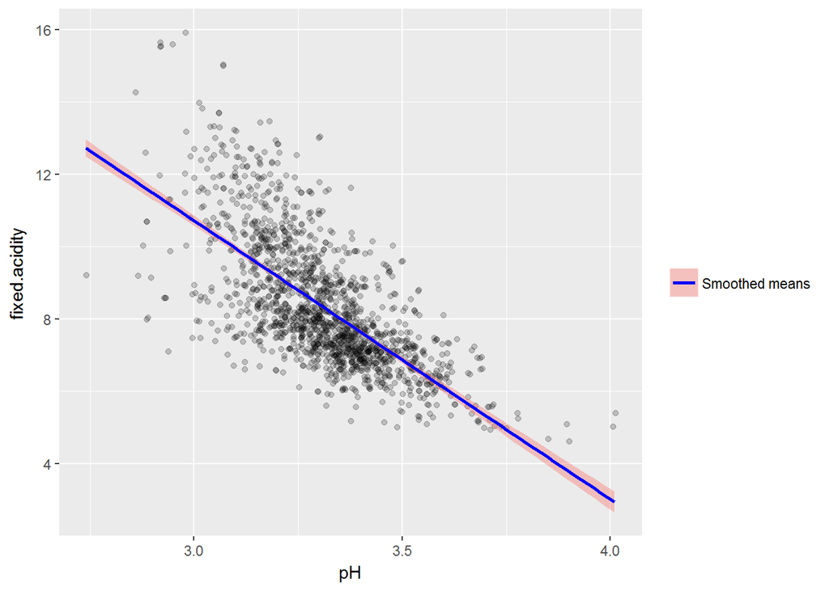

With increasing pH, fixed acidity decreases. These two variables do not influence the quality of the red wine.

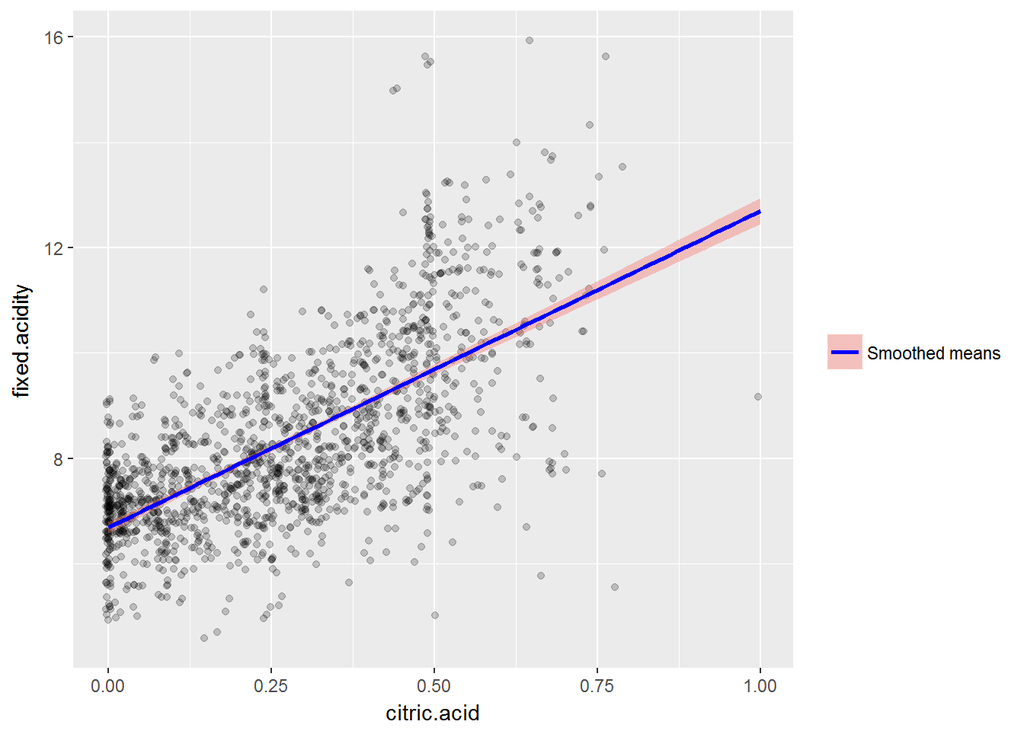

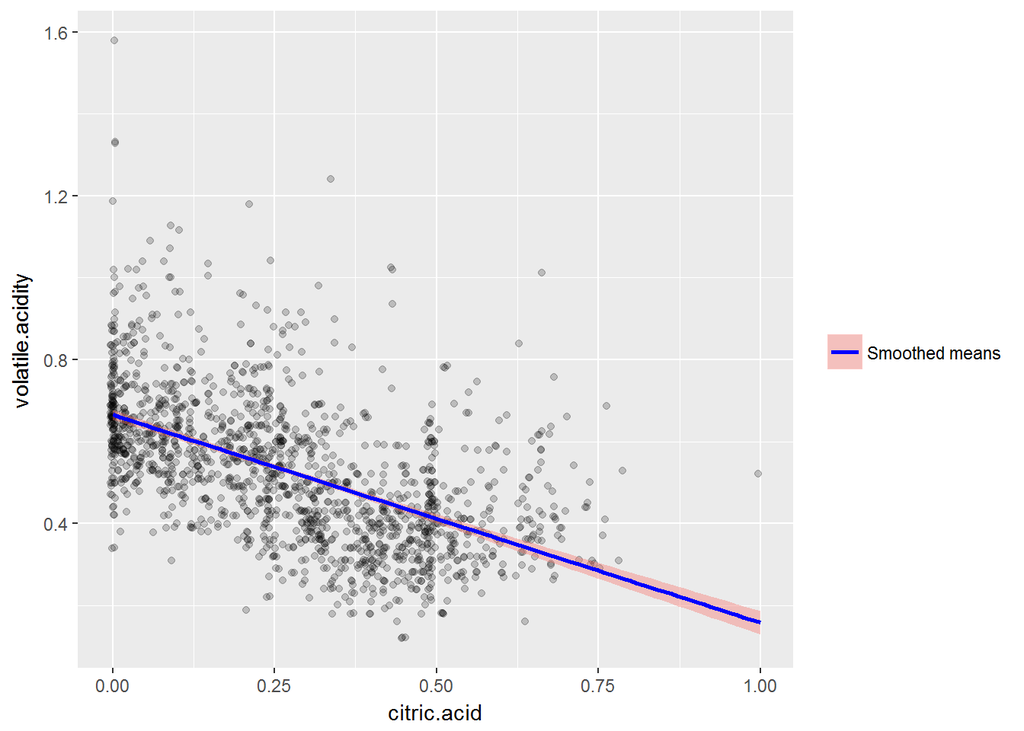

# Multivariate Plots and Analysis

We use the results of the analysis before and plot the variables with the highest correlation to the variable “quality” (alcohol, volatile acidity, sulphates and citric acid) altogether:

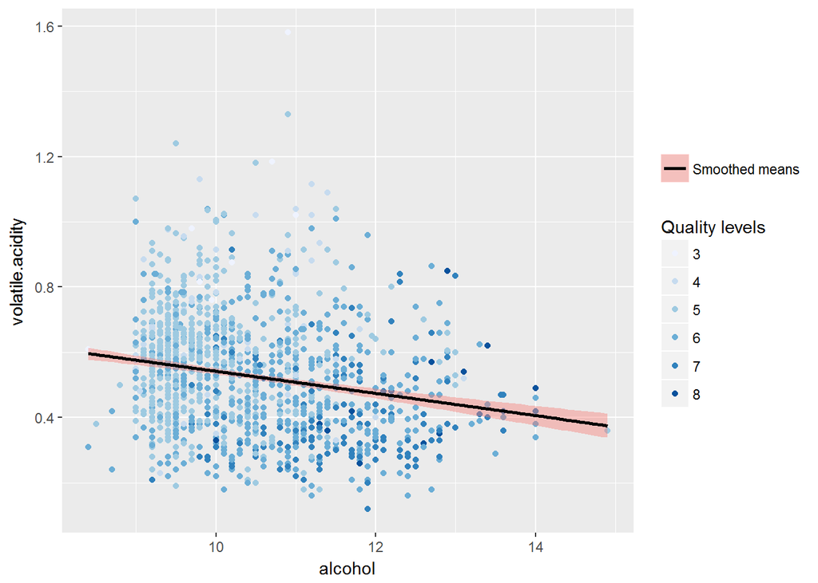

This plot shows that a higher alcohol content is accompanied by a higher quality of the wine (see quality levels). However, with increasing alcohol content, volatile acidity decreases slightly. The correlation between alcohol and volatile acidity is -0.202288027 (see table).

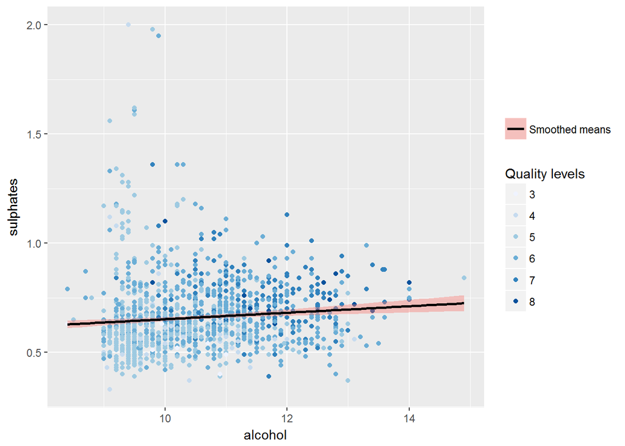

This plot shows that a higher alcohol content is accompanied by a higher quality of the wine (see quality levels). However, with increasing alcohol content, sulphates increases slightly. The correlation between alcohol and sulphates is 0.093594750 (see table).

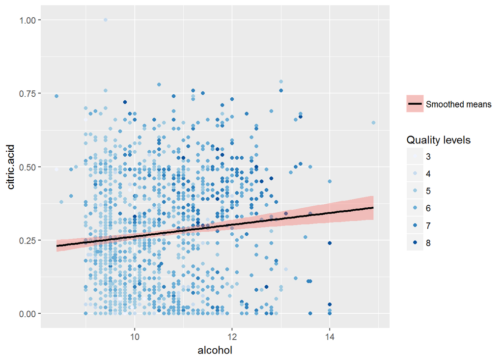

This plot shows that a higher alcohol content is accompanied by a higher quality of the wine (see quality levels). However, with increasing alcohol content, citric acids increases slightly. The correlation between alcohol and citric acid is 0.10990325 (see table).

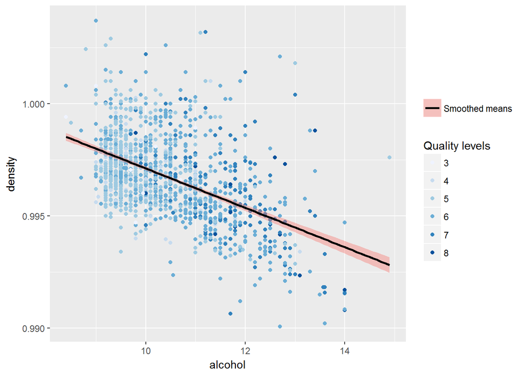

Because the correlation between alcohol and density is high (-0.4961797) these variables were plotted. This plot shows that a higher alcohol content is accompanied by a higher quality of the red wine (see quality levels). However, with increasing alcohol content, density decreases.

The above multivariate analysis illustrates the following:

- A higher alcohol correlates with a higher quality of wine
- As the alcohol content and quality of wine increases, volatile acidity decreases slightly.
- As the alcohol content and quality of wine increases, sulphates increases slightly.
- As the alcohol content and quality of wine increases, citric acids increases slightly.
- As the alcohol content and quality of wine increases, density decreases.

# Final Plots and Summary

### Plot One: Alcohol and Quality

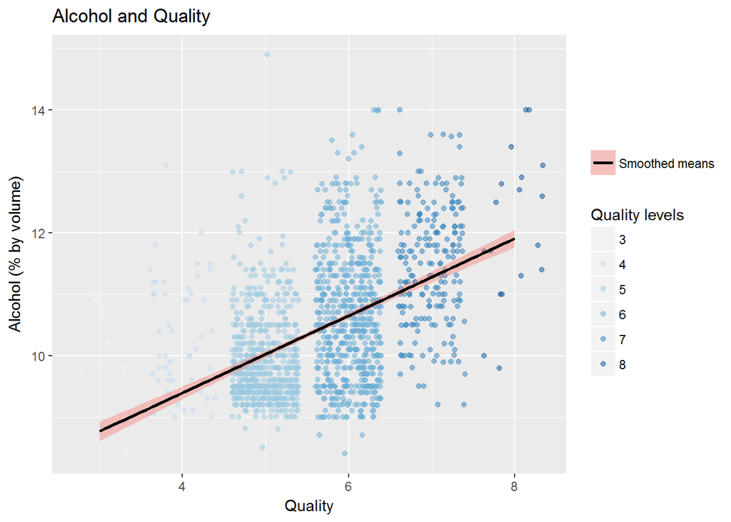

An alternative plot:

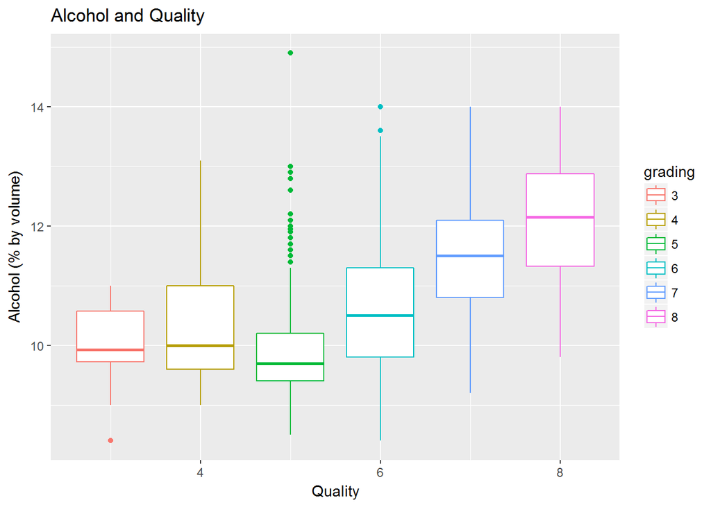

### Description One

These plots were generated to illustrate the relationships between alcohol content and the quality of the red wine. It shows that the alcohol content increases with increasing quality of the red wine.

### Plot Two: Sulphates and Quality

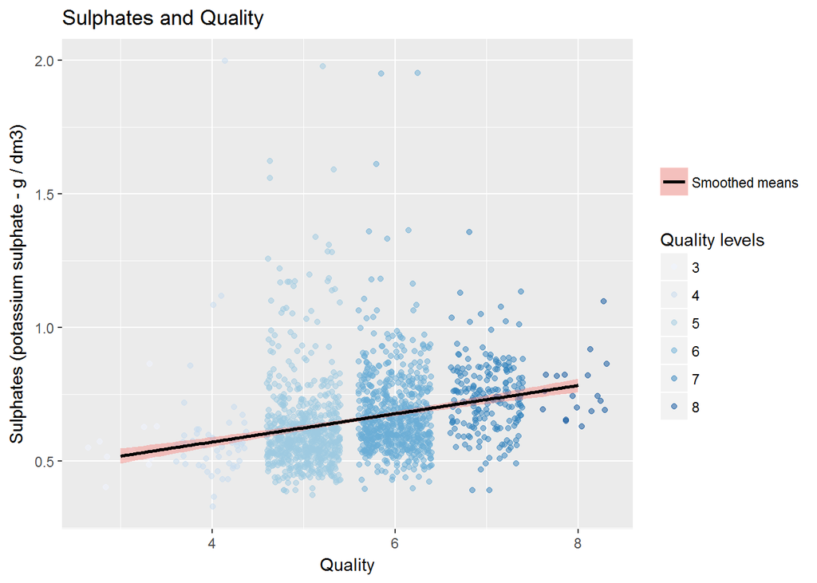

An alternative plot:

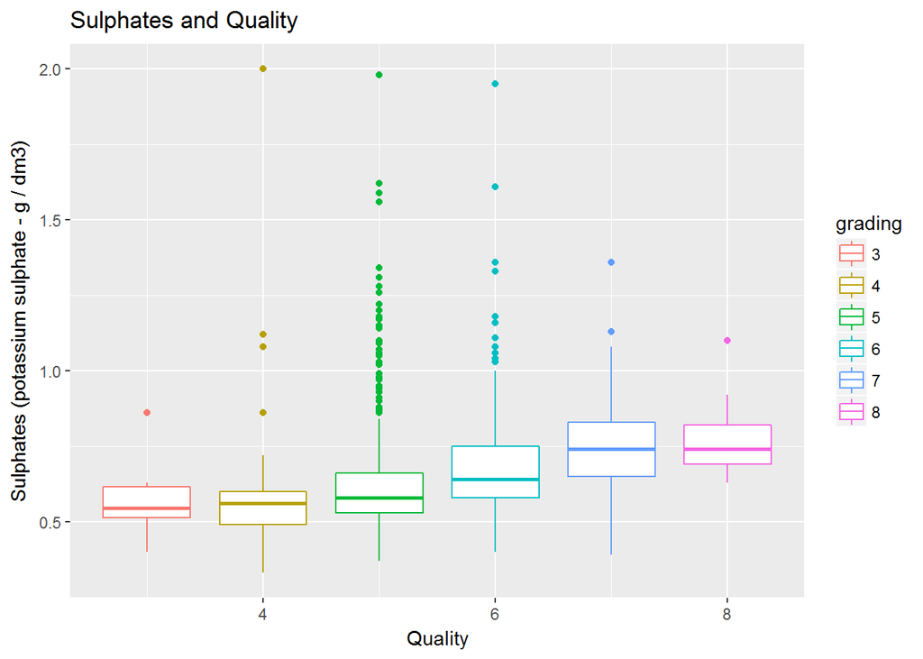

### Description Two

These plots were generated to illustrate the relationships between sulphates and the quality of the red wine. Interestingly, sulphates increase with higher red wine quality.

### Plot Three: Citric Acid and Quality

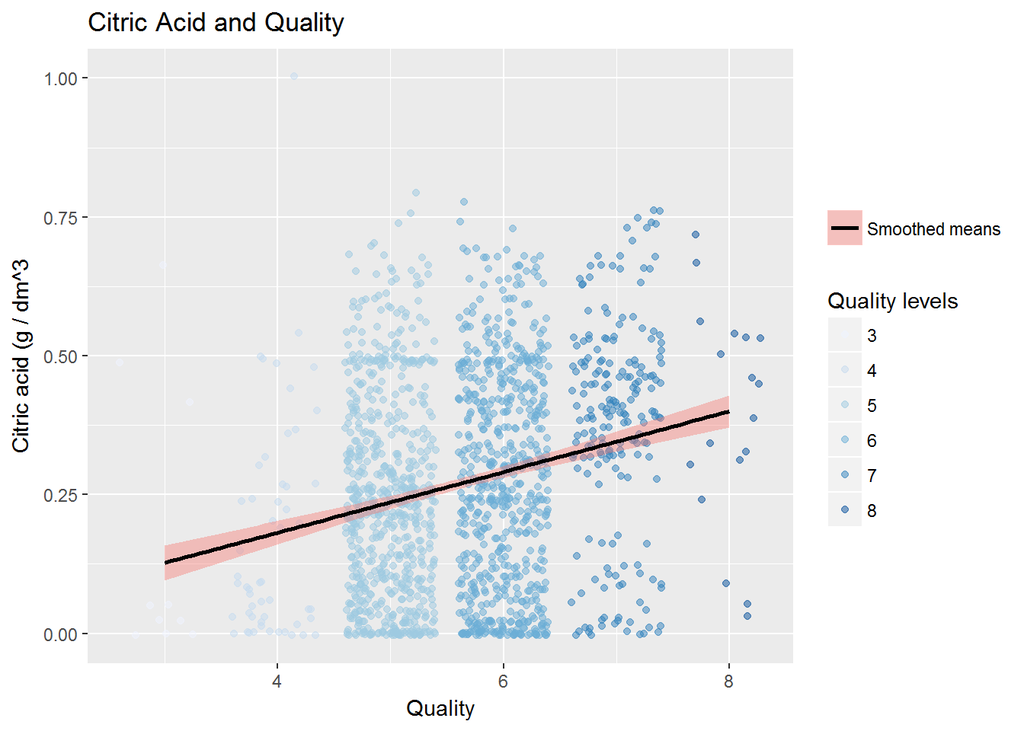

An alternative plot:

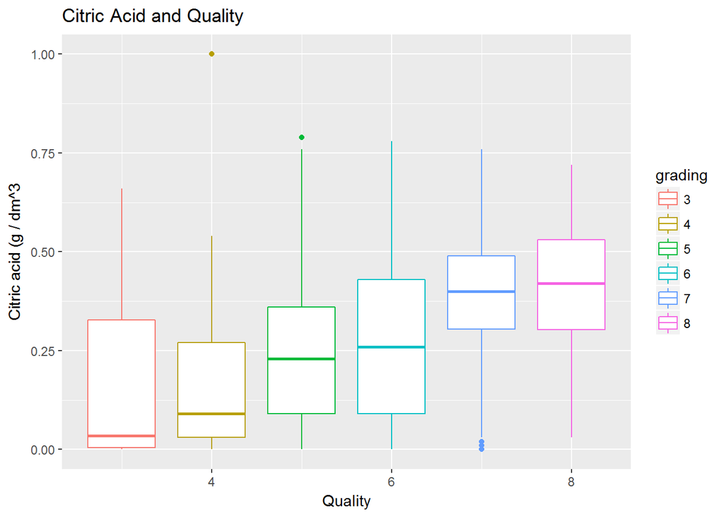

### Description Three

These plots were generated to illustrate the relationships between citric acid and the quality of the red wine. It shows that the citric acid increases with increasing quality of the red wine.

# Reflection

Overall, these analyzes have shown that the alcohol content has a measurable influence on the quality of a red wine - it increases with increasing quality of the red wine. The correlation between “alcohol” and the subjective variable “quality” is 0.4761663. Consequently “alcohol” has a small to moderate impact on red wine quality. In addition to “alcohol”, “citric acid” and “sulphates” have a very small impact on the quality of red wine and increases with increasing quality of the red wine. In addition, it should be noted that the variable of red wine quality is based on subjective perceptions of wine experts. Through a possible subjective conclusion by experts, inaccuracies can occur within this variable, which can also have a total impact on all the analyzes listed here. For future wine evaluations, a quantitative assessment by many experts would be useful: This would reduce the subjective influence and consequently a false conclusion. In addition to the alcohol content, the red wine quality is probably affected by the wine age and storage. Consequently, these variables should also be measured to gain more insights during future analysis. Finally, these analyzes have expanded my knowledge of the red wine quality.